# Sesión 4

Jorge de la Vega

11/02/2023

En la sesión de hoy cubriremos los siguientes temas:

1. Funciones para manipular datos
2. Ejemplo de análisis de datos reales

Para el ejercicio de hoy se requiere instalar algunos paquetes adicionales:

```r
# Para instalar los paquetes, descomentar las líneas siguientes y volver a comentar después de la
# instalación:

#install.packages("readr")
#install.packages("httr")
#install.packages("readxl")
#install.packages("skimr")
#install.packages("foreign")
```

# 1.Funciones especiales para la transformación de datos.

## Distribuciones Variables aleatorias

En R se pueden generar muestras de muchas distribuciones de probabilidad. Las funciones que se tienen disponibles son de la forma:

- **rNOMBREDIST**: para generar números aleatorios de la distribución NOMBREDIST
- **qNOMBREDIST**: para generar cuantiles de la distribución
- **dNOMBREDIST**: para generar valores de la función de densidad o de masa de probabilidad.
- **pNOMBREDIST**: para generar valores de la función de distribucion $F(x)$

NOMBREDIST puede ser cualquiera de las muchas distribuciones:

Y hay muchas más. Por ejemplo, para la distribución normal:

```r
x <- rnorm(n = 1000, mean = 2.4, sd = 4) # muestra de N(2.4,16)
head(x)
```

```
[1]  6.576694  4.122132 -0.639160  2.212282  7.915019  2.529370
```

```r
tail(x,10)
```

```
 [1]  7.6006558  7.1317035  2.8747716  0.3711124  7.6912723 -4.4567954  3.0039890  3.6547432 -1.1516870  0.1190931
```

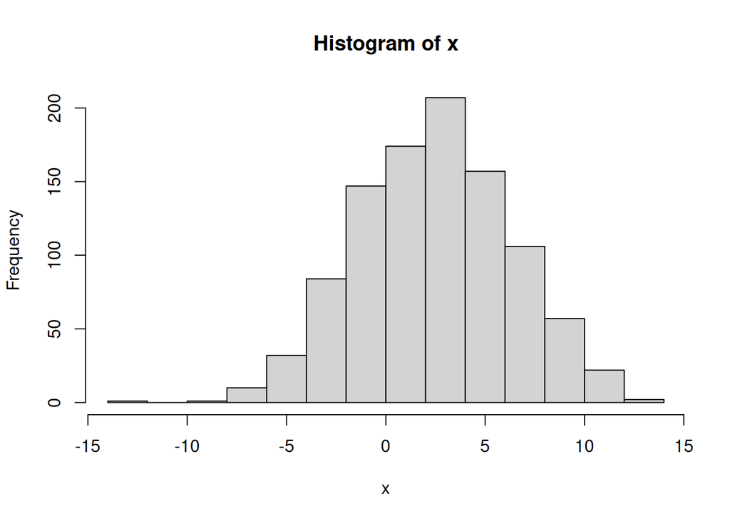

```r
hist(x)
```

```r
mean(x)
```

```
[1] 2.434379
```

```r
sd(x)
```

```
[1] 3.853873
```

```r
qnorm(0.95) # devuelve el valor de x que acumula 95% de la probabilidad para una N(0,1)
```

```
[1] 1.644854
```

```r
qnorm(0.95, mean = 2.4, sd = 4)
```

```
[1] 8.979415
```

```r
dnorm(0.95)  # da el valor de la curva normal N(0,1) en 0.95
```

```
[1] 0.2540591
```

```r
pnorm(1.645)
```

```
[1] 0.9500151
```

Para graficar la famosa curva normal

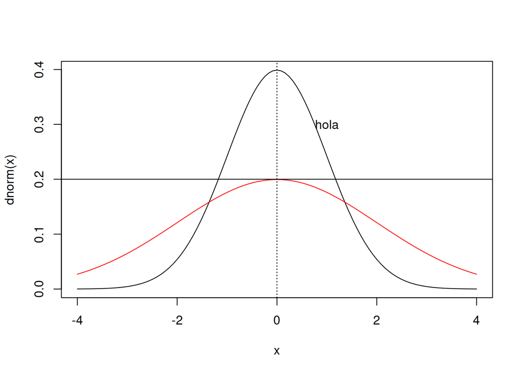

```r
curve(dnorm(x), from = -4, to = 4)
curve(dnorm(x, sd = 2), from =-4, to = 4, col ="red", add = T)
abline(h=0.2)
abline(v=0, lty = 3)
text(1,0.3,"hola")
```

Para nuestros ejercicios creamos una matriz artificial de datos

```r
# Creamos una matriz artificial
X <- rnorm(100)
dim(X) <- c(10,10)
X
```

```
              [,1]       [,2]        [,3]       [,4]        [,5]       [,6]        [,7]       [,8]        [,9]       [,10]
 [1,]  0.990300331  1.3436019  0.00845810  2.0967194 -1.16789143 -1.1939608  0.57761812 -0.5436158  1.22592099 -1.42608997
 [2,]  0.003696838  0.7478655 -0.50543038  2.6226557  0.53404329 -0.9496017  0.67412110 -0.4084874 -0.15395751  0.44571492
 [3,] -1.443893375 -1.0048210  0.34544792  0.3906264  1.69475541 -0.2492266  0.51813142  0.6374937 -0.26173492 -0.90081957
 [4,]  0.417205741 -0.7891290  0.04305432  0.5724936  1.12594608 -1.1616559  0.60127110  0.1246017 -2.13543851  1.29885946
 [5,] -0.413456028 -0.8645716 -0.93984204  0.8748187  0.99001502 -0.6210381  1.77979730  0.6408026  1.28357797 -0.09185255
 [6,]  0.786142401 -0.7150328  0.68459213 -1.4685793  0.74537239  0.6063595 -0.17053386 -1.0340956  0.06573697  0.97673950
 [7,]  0.995570074  0.5366390  2.29652812 -0.6597462  1.02206624 -0.3357669  0.40175044 -0.6960949 -0.92406628  0.24033035
 [8,]  1.080412809  0.8172267 -0.88956013 -0.6086505  0.02184590 -1.5432216 -0.87100630 -1.0230880  2.64386092  0.02303198
 [9,]  1.333984225 -0.0426184  0.34665129  1.5242611 -0.48662389  2.5824289  0.07170206  0.2081396  0.02521665  0.54333611
[10,]  0.055284256  0.6268526  1.37462276 -0.6003326  0.09853923 -0.3148630  0.08871529 -0.4370803 -0.63854387  1.98284667
```

## 2. Uso de las funciones `apply`, `lapply`, `tapply`, `mapply` y `sapply`

Estas funciones pueden funcionar a veces como alternativas a los loops.

La función `apply` permite aplicar otras funciones sobre los renglones o las columnas de una matriz.

Ejemplo: supongan que quieren la media en cada renglón de la matriz `X`

```r
apply(X = X, MARGIN = 1, FUN = mean) # el uno indica que queremos renglones
```

```
 [1]  0.191106079  0.301062033 -0.027404060  0.009720849  0.263825133  0.047670122  0.287720985 -0.034914824  0.610647763  0.223604114
```

```r
mean(X[1,])
```

```
[1] 0.1911061
```

```r
apply(X, 2, sum)                     # obtiene la suma por columnas
```

```
 [1]  3.8052473  0.6560127  2.7645221  4.7442664  4.5780682 -3.1805461  3.6715667 -2.5314245  1.1305724  3.0920969
```

```r
# aplicar una función creada "al vuelo"
apply(X,1,function(x){sqrt(sum(x^2))})
```

```
 [1] 3.759994 3.118287 2.802778 3.219903 3.027734 2.595132 3.115031 3.764947 3.387466 2.700586
```

También podemos definir nuestras propias funciones. Por ejemplo, si queremos elevar al cuadrado y sumar los valores podemos crear nuestra propia función

```r
apply(X, 2, function(x)sum(x^2))
```

```
 [1]  7.969585  6.606316  9.803802 18.166418  8.616442 13.754554  5.547896  4.129904 16.059355  9.978547
```

La función equivalente para listas es la función `lapply`, que aplica una función a cada componente de una lista

Ejemplo: creamos una lista con las columnas de X

```r
lista <- list(NULL)
length(lista) <- 10
for(i in 1:10) lista[[i]] <- X[,i]  # definimos los elementos de la lista

Z <- lapply(lista,max)   # saca el max de cada lista
Z <- unlist(Z) # convierte la lista a vector.
Z2 <- lapply(lista,function(x)c(min(x),median(x),max(x)))
```

El resultado es una lista, lo podemos convertir a un vector

```r
unlist(Z)
```

```
 [1] 1.3339842 1.3436019 2.2965281 2.6226557 1.6947554 2.5824289 1.7797973 0.6408026 2.6438609 1.9828467
```

La función `sapply` es similar a `lapply` pero trata de simplificar la salida a la estructura de datos más simple posible. En el caso previo, ya no tendríamos que unlistar la función:

```r
sapply(lista,max)
```

```
 [1] 1.3339842 1.3436019 2.2965281 2.6226557 1.6947554 2.5824289 1.7797973 0.6408026 2.6438609 1.9828467
```

```r
Z3 <- sapply(lista, function(x)c(min(x),median(x),max(x)))
```

La función `tapply` aplica funciones sobre *grupos* de un dataframe, que se pueden identificar con una variable *etiqueta*: esto es parecido o equivalente a las tables dinámicas de Excel.

Ejemplo: supongamos que cada uno de los renglones corresponde a datos de cuatro países.

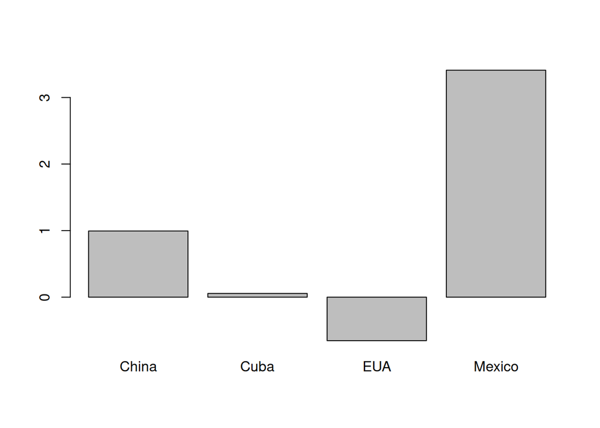

```r
paises <- c("China", "China", "EUA", "EUA", "EUA", "EUA", "Mexico", "Mexico", "Mexico", "Cuba")
X <- as.data.frame(X) # convertimos matriz a data frame
U1 <- tapply(X$V1, paises, sum)
U2 <- tapply(X[,1], paises, mean)

#Podemos hace una gráfica de barras con estos datos
barplot(U1)
```

Podemos usar dos variables o las que sean necesarias para hacer cálculos por grupos

```r
sexo <- c(rep("H",5), rep("M",5))
tapply(X$V2, list(paises, sexo), sum) # requiere que las variables que particionan esten
```

```
               H          M
China   2.091467         NA
Cuba          NA  0.6268526
EUA    -2.658522 -0.7150328
Mexico        NA  1.3112472
```

```r
# en una lista.
```

La función `mapply`es como un `apply` multivariado. Su propósito es hacer las operaciones sobre una lista múltiple o sobre varios vectores

```r
mapply(rep, 1:4, 4:1) #rep(1,4), rep(2,3), rep(3,2), rep(4,1)
```

```
[[1]]
[1] 1 1 1 1

[[2]]
[1] 2 2 2

[[3]]
[1] 3 3

[[4]]
[1] 4
```

```r
mapply(sum,list(X[,1],X[,2]),1:2) #suma elementos de columna 1 y le agrega 1, suma elementos de columna 2 y agrega 2.
```

```
[1] 4.805247 2.656013
```

# 3. Análisis de datos

Leamos archivos simples.

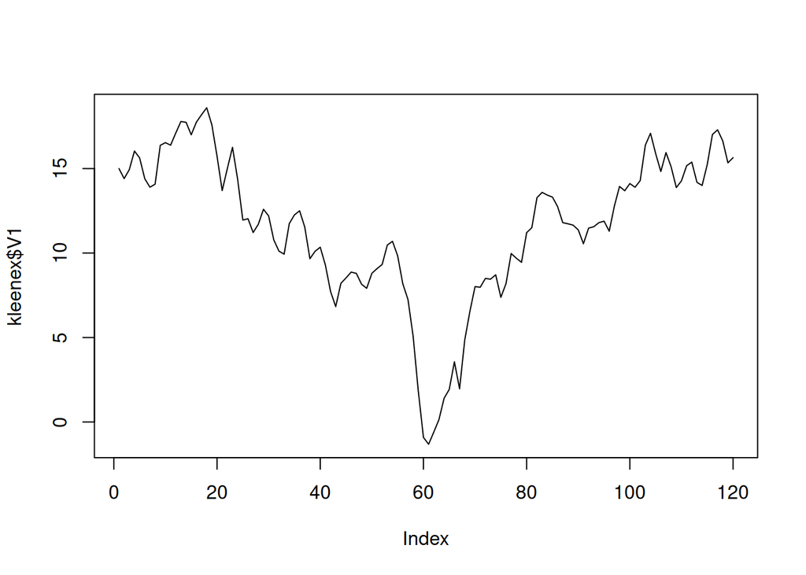

```r
kleenex <- read.delim(file = "https://jvega68.github.io/R_docentes/datos/kleenex.txt", header = F)
plot(kleenex$V1, type = "l")
```

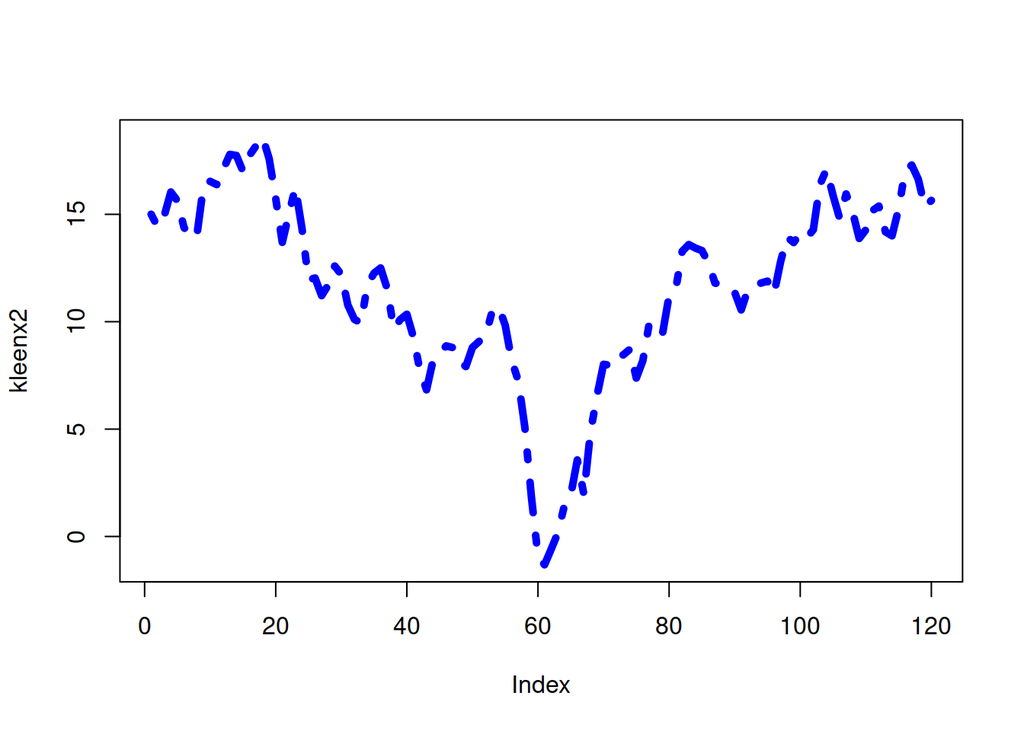

```r
kleenx2 <- scan(file = "https://jvega68.github.io/R_docentes/datos/kleenex.txt")
plot(kleenx2, type = "l", col = "blue", lwd = 5, lty = 4)
```

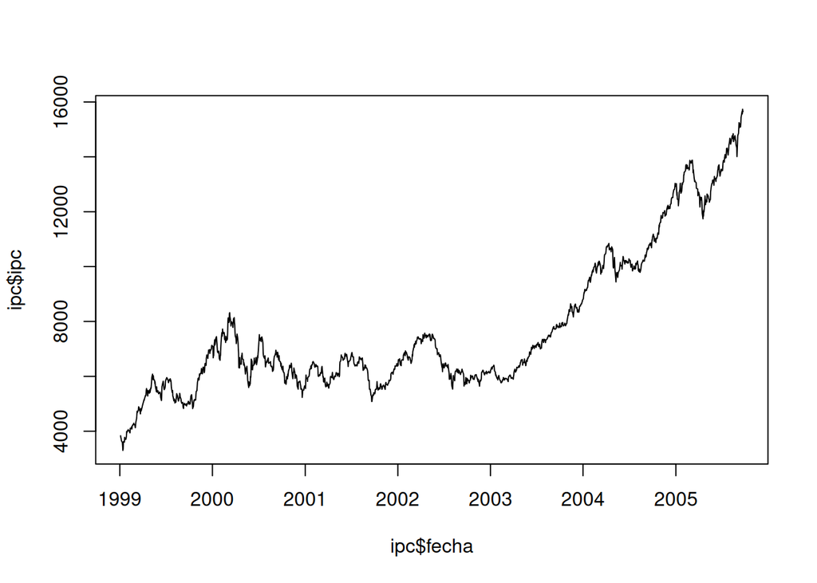

```r
ipc <- read.delim(file = "https://jvega68.github.io/R_docentes/datos/ipcbmv1999-2005.txt", sep = ",")
# convierte el vector de caracteres de texto a fechas
ipc$fecha <- as.Date(ipc$fecha, format = "%d/%m/%Y")
# el formato lo pueden consultar en el help de  format.POSIXct.
plot(ipc$fecha, ipc$ipc, type = "l")
```

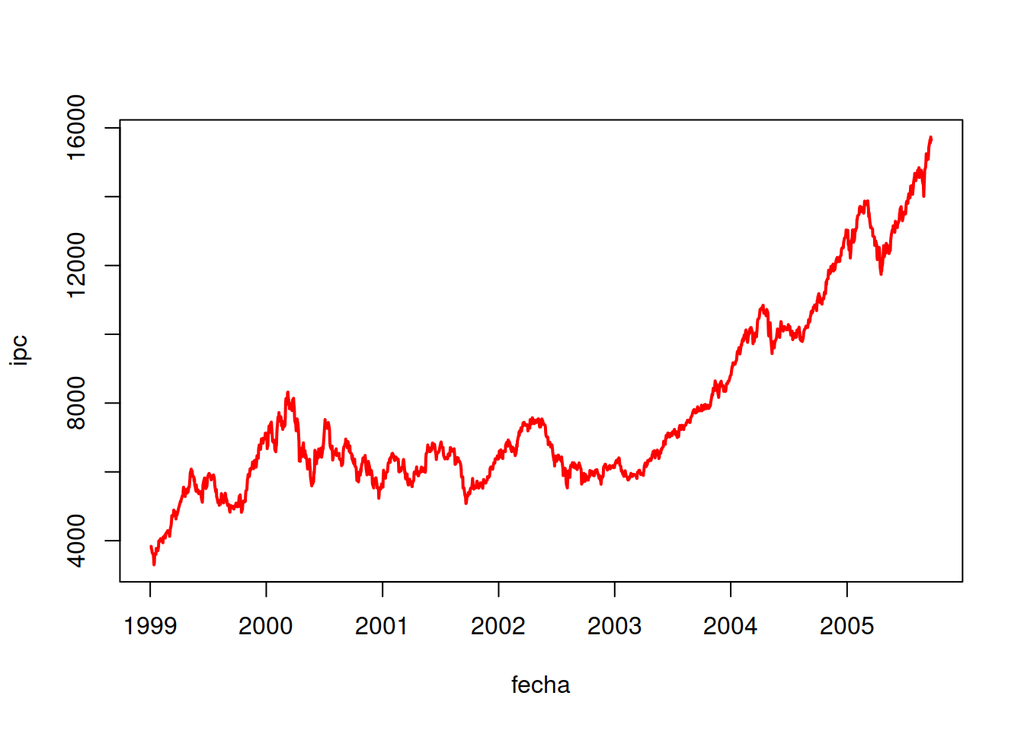

```r
# lo mismo se puede hacer con:
with(ipc, plot(fecha,ipc,type = "l", col = "red", lwd= 2))
```

```r
heart <- read.csv(file = "https://jvega68.github.io/R_docentes/datos/heart_failure_clinical_records_dataset.csv")
str(heart)
```

```
'data.frame':   299 obs. of  13 variables:
 $ age                     : num  75 55 65 50 65 90 75 60 65 80 ...
 $ anaemia                 : int  0 0 0 1 1 1 1 1 0 1 ...
 $ creatinine_phosphokinase: int  582 7861 146 111 160 47 246 315 157 123 ...
 $ diabetes                : int  0 0 0 0 1 0 0 1 0 0 ...
 $ ejection_fraction       : int  20 38 20 20 20 40 15 60 65 35 ...
 $ high_blood_pressure     : int  1 0 0 0 0 1 0 0 0 1 ...
 $ platelets               : num  265000 263358 162000 210000 327000 ...
 $ serum_creatinine        : num  1.9 1.1 1.3 1.9 2.7 2.1 1.2 1.1 1.5 9.4 ...
 $ serum_sodium            : int  130 136 129 137 116 132 137 131 138 133 ...
 $ sex                     : int  1 1 1 1 0 1 1 1 0 1 ...
 $ smoking                 : int  0 0 1 0 0 1 0 1 0 1 ...
 $ time                    : int  4 6 7 7 8 8 10 10 10 10 ...
 $ DEATH_EVENT             : int  1 1 1 1 1 1 1 1 1 1 ...
```

```r
heart$sex <- factor(heart$sex,
                    levels = c(0,1),
                    labels = c("Hombres","Mujeres"))
heart$diabetes <- factor(heart$diabetes,
                         levels = c(0,1),
                         labels = c("Sin diabetes","Con diabetes"))
summary(heart)
```

```
      age           anaemia       creatinine_phosphokinase         diabetes   ejection_fraction high_blood_pressure   platelets
 Min.   :40.00   Min.   :0.0000   Min.   :  23.0           Sin diabetes:174   Min.   :14.00     Min.   :0.0000      Min.   : 25100
 1st Qu.:51.00   1st Qu.:0.0000   1st Qu.: 116.5           Con diabetes:125   1st Qu.:30.00     1st Qu.:0.0000      1st Qu.:212500
 Median :60.00   Median :0.0000   Median : 250.0                              Median :38.00     Median :0.0000      Median :262000
 Mean   :60.83   Mean   :0.4314   Mean   : 581.8                              Mean   :38.08     Mean   :0.3512      Mean   :263358
 3rd Qu.:70.00   3rd Qu.:1.0000   3rd Qu.: 582.0                              3rd Qu.:45.00     3rd Qu.:1.0000      3rd Qu.:303500
 Max.   :95.00   Max.   :1.0000   Max.   :7861.0                              Max.   :80.00     Max.   :1.0000      Max.   :850000
 serum_creatinine  serum_sodium        sex         smoking            time        DEATH_EVENT
 Min.   :0.500    Min.   :113.0   Hombres:105   Min.   :0.0000   Min.   :  4.0   Min.   :0.0000
 1st Qu.:0.900    1st Qu.:134.0   Mujeres:194   1st Qu.:0.0000   1st Qu.: 73.0   1st Qu.:0.0000
 Median :1.100    Median :137.0                 Median :0.0000   Median :115.0   Median :0.0000
 Mean   :1.394    Mean   :136.6                 Mean   :0.3211   Mean   :130.3   Mean   :0.3211
 3rd Qu.:1.400    3rd Qu.:140.0                 3rd Qu.:1.0000   3rd Qu.:203.0   3rd Qu.:1.0000
 Max.   :9.400    Max.   :148.0                 Max.   :1.0000   Max.   :285.0   Max.   :1.0000
```

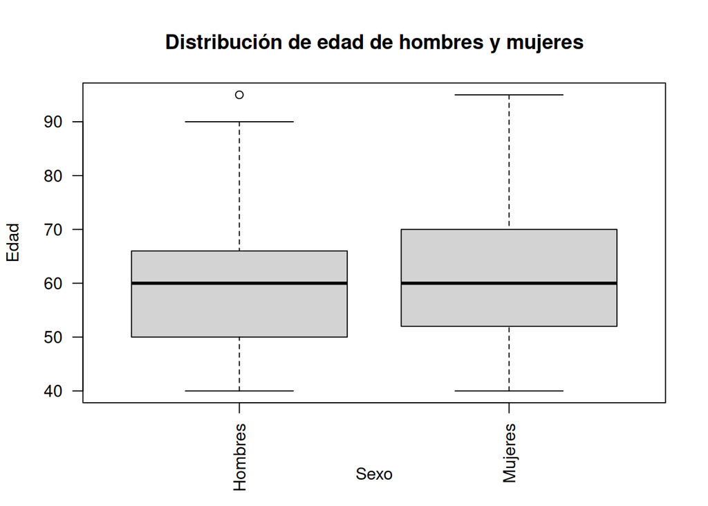

```r
boxplot(heart$age ~ heart$sex,
        las = 2,
        xlab = "Sexo",
        ylab = "Edad",
        main = "Distribución de edad de hombres y mujeres")
```

Tomemos datos de [Our World in data](https://github.com/owid/covid-19-data/tree/master/public/data). Leeremos los datos en formato csv y formato de Excel, para ver cómo podemos trabajar con este tipo de archivos

Formato csv:

```r
datos1 <- read.csv(file = "https://covid.ourworldindata.org/data/owid-covid-data.csv")
```

en formato Excel: Aquí hay un problema, porque la función que lee en Excel no tiene que leer el archivo localmente. Entonces hay dos opciones:

- copiar el archivo al directorio de trabajo
- leer el archivo remoto a un archivo local temporal y leer el archivo.

Iremos por la segunda vía, para aprender cómo hacerlo.

```r
library(readxl) # no puede leer archivo de la red, aśí que podemos primero traer el archivo
library(httr) # paquete que facilita el acceso a archivos de la red
url <- "https://covid.ourworldindata.org/data/owid-covid-data.xlsx"
GET(url, write_disk(archivo_temporal <- tempfile(fileext = ".xlsx")))
```

```
Response [https://covid.ourworldindata.org/data/owid-covid-data.xlsx]
  Date: 2023-02-18 00:47
  Status: 200
  Content-Type: binary/octet-stream
  Size: 43.8 MB
<ON DISK>  /tmp/RtmpVJI5G1/file75f04a566971.xlsx
```

```r
datos2 <- read_xlsx(archivo_temporal)
```

Ejercicio: Calcular el número de casos nuevos por país y por continente

```r
# Número de casos por continente
tapply(datos2$new_cases, datos2$continent, sum, na.rm = T)
```

```
       Africa          Asia        Europe North America       Oceania South America
     12498455     208827239     247066580     121885860      13986413      67707929
```

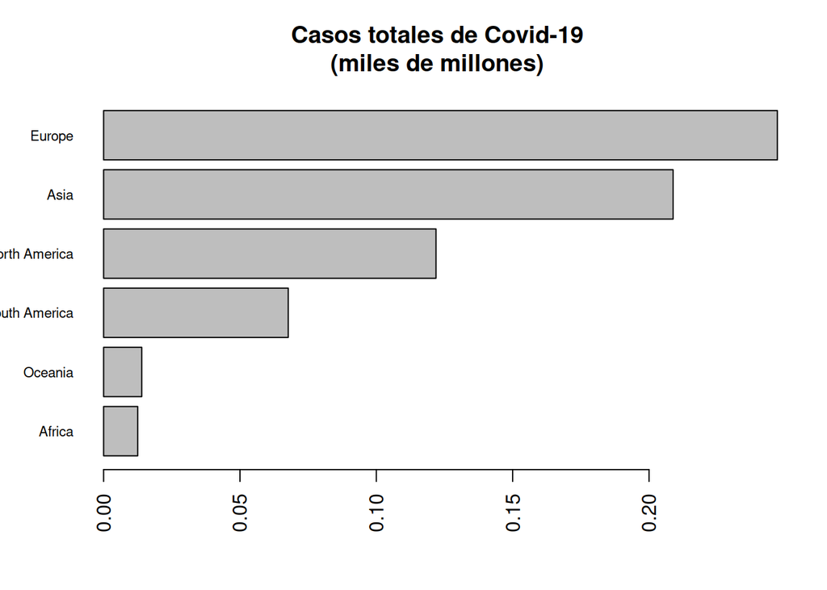

```r
casos_por_continente <- tapply(datos2$new_cases, datos2$continent, sum, na.rm = T)
# ordena los casos de mayor a menor para graficar
y <- casos_por_continente[order(casos_por_continente)]
barplot(height = y/1e9, # Gráfica de barras
        las = 2, # pone las etiquetas de forma vertical, para facilitar su lectura
        horiz = T, # hace la gráfica de barras horizontales
        cex.names = 0.7, # escala el tamaño de las etiquetas
        main = "Casos totales de Covid-19\n(miles de millones)" )
```

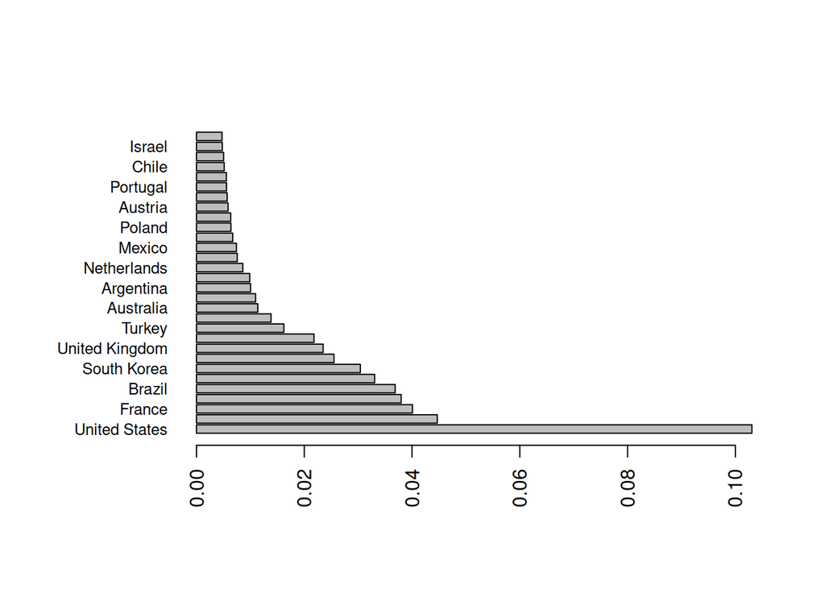

```r
# Quitamos los datos globales y sólo consideramos por países
datos_pais <- datos2[!(datos2$location %in% c("World","High income", "Upper middle income", "Lower middle income",
                                              "European Union", unique(datos2$continent))), ]


casos_por_pais <- tapply(datos_pais$new_cases, datos_pais$location, sum, na.rm = T)
x <- casos_por_pais[order(casos_por_pais,decreasing = T)]/1e9
par(oma = c(1,4,1,1)) # modifica los "outer margins"
barplot(height = x[1:30] , las = 2, cex.names = 0.8, horiz = T)
```

```r
Z <- tapply(datos2$new_cases,list(datos2$date, datos2$continent),sum,na.rm=T)
head(Z)
```

```
           Africa Asia Europe North America Oceania South America
2020-01-01     NA   NA     NA             0      NA             0
2020-01-02     NA   NA     NA             0      NA             0
2020-01-03     NA   NA     NA             0      NA             0
2020-01-04     NA    0     NA             0      NA             0
2020-01-05     NA    0     NA             0      NA             0
2020-01-06     NA    0      0             0      NA             0
```

```r
tail(Z)
```

```
           Africa  Asia Europe North America Oceania South America
2023-02-12     85 38544  21757          3377    8364          4641
2023-02-13   2829 38948  47012         23595     296         23704
2023-02-14    556 69992  52583         62202     326          6570
2023-02-15    851 66196  56872         93311      11         20783
2023-02-16    766 51535  73612         66212   13117          2173
2023-02-17     NA     0      0            NA      NA            NA
```

Para poder graficar las series de tiempo, necesitamos convertir las fechas que estan como texto a fechas

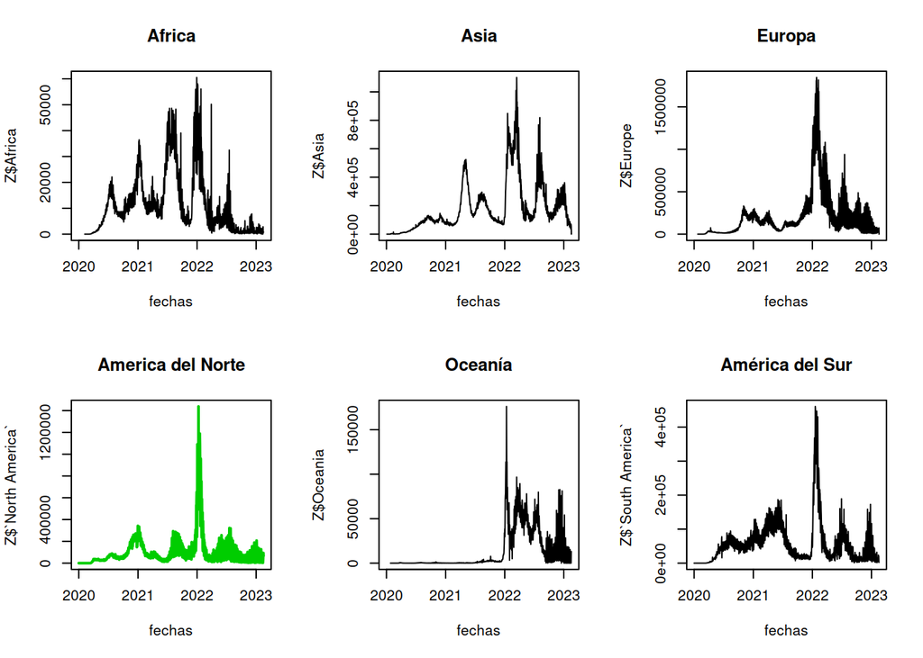

```r
Z <- as.data.frame(tapply(datos2$new_cases, list(datos2$date, datos2$continent), sum, na.rm = T))
fechas <- as.Date(row.names(Z)) # crea un vector con las fechas en el formato adecuado de fecha
# vamos a graficar un arreglo de 2x3=6 gráficas. Las gráficas se llenarán por renglones con mfrow
par(mfrow=c(2,3)) # par es una función que define parámetros gráficos.
# Añadimos una a una las gráficas por continente:
plot(fechas,Z$Africa,type ="l", main ="Africa")
plot(fechas,Z$Asia,type ="l", main ="Asia")
plot(fechas,Z$Europe,type ="l", main ="Europa")
plot(fechas,Z$`North America`,type ="l", main ="America del Norte", col ="green3",lwd =2)
plot(fechas,Z$Oceania,type ="l", main ="Oceanía")
plot(fechas,Z$`South America`,type ="l", main ="América del Sur")
```

Analicemos la información de los vacunados, para México.

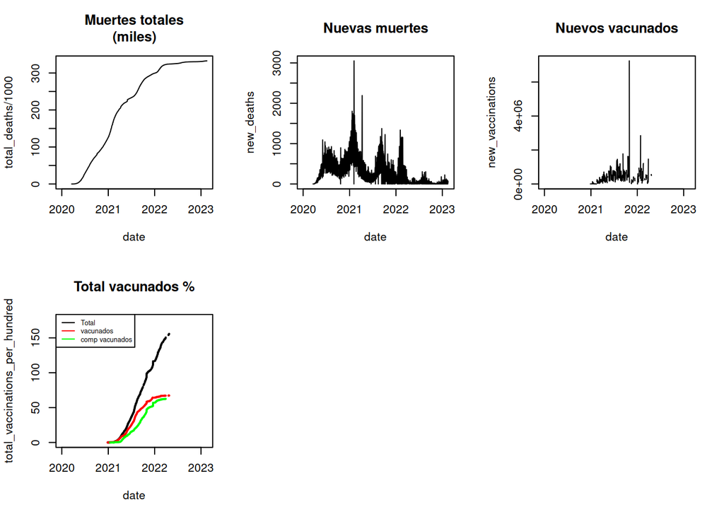

```r
# Extraemos los datos correspondientes a México.
mex <- subset(datos2,
              subset = location == "Mexico",
              select =c(date,
                        total_deaths,
                        new_deaths,
                        new_vaccinations,
                        total_vaccinations_per_hundred,
                        people_vaccinated_per_hundred,
                        people_fully_vaccinated_per_hundred))
mex$date <- as.Date(mex$date) # cambiamos el formato de las fechas. Antes lo hicimos afuera
par(mfrow=c(2,3))
with(mex, plot(date, total_deaths/1000, type ="l", main ="Muertes totales\n(miles)"))
with(mex, plot(date,new_deaths, type ="l", main ="Nuevas muertes"))
with(mex, plot(date,new_vaccinations, type ="l", main ="Nuevos vacunados"))
# se grafican tres lineas en la misma gráfica
with(mex, plot(date,total_vaccinations_per_hundred, type ="l", main ="Total vacunados %", lwd =2))
with(mex, lines(date,people_vaccinated_per_hundred, type ="l",  col = "red", lwd =2))
with(mex, lines(date,people_fully_vaccinated_per_hundred, type ="l", col  = "green", lwd=2))
legend("topleft",legend = c("Total","vacunados","comp vacunados"),
                    col = c("black","red","green"),
                    lty = rep(1,3), cex = 0.6)
```

Se puede encontrar un resumen básico para hacer gráficas en [este documento.](https://dcgerard.github.io/stat234/base_r_cheatsheet.html)

## Otro ejemplo con datos de la ENIGH 2020

En esta sección veremos cómo analizar un conjunto de datos con herramientas de la Estadística descriptiva. Para esto usaremos los microdatos de la Encuesta ENIGH 2020 que publicó el Inegi recientemente. Los detalles de la encuesta se encuentran en el micrositio sigiuente: [Sitio Enigh 2020](https://www.inegi.org.mx/programas/enigh/nc/2020/). Nos concentraremos en las características sociodemográficas de la población.

```r
library(readr) # Este paquete lee archivos en formato de texto. Es más rápido que la función de default de R y
# permite leer datos que están comprimidos.
url <- "https://www.inegi.org.mx/contenidos/programas/enigh/nc/2020/microdatos/enigh2020_ns_poblacion_csv.zip"
temp <- tempfile()
download.file(url, destfile = temp, mode="wb")
datos <- read_csv(unzip(temp),show_col_types = F)
```

La descripción de los datos de la base de viviendas se encuentra en el siguiente documento: [Descripción de las Bases de Datos](https://www.inegi.org.mx/contenidos/productos/prod_serv/contenidos/espanol/bvinegi/productos/nueva_estruc/889463901242.pdf)

Vamos a concentrarnos en algunas variables para realizar los ejercicios de manera rápida, dado que la base tiene 184 variables y 315,743 registros. Nos concentraremos en las siguientes variables:

- `folioviv`: Identificador de la vivienda. tiene en el identificador la entidad federativa y otros componentes.
- `edad`: edad de la persona de la entrevista (años) ¿Cuántos años cumplidos?
- `sexo`: distinción biológica que clasifica a las personas en hombres y mujeres.
- `cau_oir`: Causa de discapacidad para escuchar.
  - 1 = Por una enfermedad
  - 2 = Por edad avanzada
  - 3 = Porque nació así
  - 4 = Por un accidente
  - 5 = Por violencia
  - 6 = Por otra causa
- `nivel`: nivel escolar al que asiste el integrante del hogar de 3 o más años
- `mm_esp`: tiempo de espera en recibir atención médica

Además, agreguemos la variable que corresponde a la entidad de la República, que son los dos primeros dígitos del folio de la vivienda.

```r
datos2 <- datos[ , c("folioviv", "edad", "sexo", "cau_oir", "mm_esp")]
datos2$entidad <- substr(datos2$folioviv,1,2)
datos2
```

```
# A tibble: 315,743 × 6
   folioviv    edad  sexo cau_oir mm_esp entidad
   <chr>      <dbl> <dbl> <chr>    <dbl> <chr>
 1 0100013605    48     2 <NA>        20 01
 2 0100013605    17     2 <NA>        30 01
 3 0100013605    14     1 <NA>        30 01
 4 0100013606    46     1 <NA>        15 01
 5 0100013606    43     2 <NA>        30 01
 6 0100013606    17     1 <NA>        30 01
 7 0100013606    11     1 <NA>        15 01
 8 0100017801    26     1 <NA>         0 01
 9 0100017801    26     2 <NA>        NA 01
10 0100017802    29     1 <NA>        10 01
# … with 315,733 more rows
```

Podemos ver las estadísticas descriptivas de la estructura de los datos:

```r
library(skimr)
skim(datos2)
```

Data summary

| Name | datos2 |
| --- | --- |
| Number of rows | 315743 |
| Number of columns | 6 |
| _______________________ |  |
| Column type frequency: |  |
| character | 3 |
| numeric | 3 |
| ________________________ |  |
| Group variables | None |

**Variable type: character**

| skim_variable | n_missing | complete_rate | min | max | empty | n_unique | whitespace |
| --- | --- | --- | --- | --- | --- | --- | --- |
| folioviv | 0 | 1.00 | 10 | 10 | 0 | 87754 | 0 |
| cau_oir | 303420 | 0.04 | 1 | 1 | 0 | 7 | 0 |
| entidad | 0 | 1.00 | 2 | 2 | 0 | 32 | 0 |

**Variable type: numeric**

| skim_variable | n_missing | complete_rate | mean | sd | p0 | p25 | p50 | p75 | p100 | hist |
| --- | --- | --- | --- | --- | --- | --- | --- | --- | --- | --- |
| edad | 0 | 1.00 | 32.78 | 21.65 | 0 | 15 | 30 | 49 | 110 | ▇▆▅▂▁ |
| sexo | 0 | 1.00 | 1.51 | 0.50 | 1 | 1 | 2 | 2 | 2 | ▇▁▁▁▇ |
| mm_esp | 114081 | 0.64 | 13.14 | 12.43 | 0 | 1 | 10 | 20 | 59 | ▇▂▃▁▁ |

Hagamos un histograma de la edad. ¿Se ve bien?

```r
table(datos2$edad) # genera tablas de frecuencias de datos discretos.
```

```
   0    1    2    3    4    5    6    7    8    9   10   11   12   13   14   15   16   17   18   19   20   21   22   23   24   25   26   27
3818 4129 4760 4907 5076 5238 5209 5431 5519 5675 5885 5753 5912 5702 5697 5790 5606 5722 5983 5225 6056 5115 5263 4924 4792 5055 4693 4566
  28   29   30   31   32   33   34   35   36   37   38   39   40   41   42   43   44   45   46   47   48   49   50   51   52   53   54   55
4742 4190 5237 3657 4444 3957 3946 4284 4236 3937 4466 3860 5067 3329 4585 4073 3745 4401 3805 4110 4218 3903 4487 3045 3825 3374 3543 3429
  56   57   58   59   60   61   62   63   64   65   66   67   68   69   70   71   72   73   74   75   76   77   78   79   80   81   82   83
3272 2840 3031 2659 3375 2122 2623 2555 2261 2502 1938 1897 2031 1601 1985 1253 1570 1421 1384 1363 1187  958 1114  802 1046  577  676  585
  84   85   86   87   88   89   90   91   92   93   94   95   96   97   98   99  100  101  102  103  104  105  107  108  110
 616  603  473  397  326  238  284  119  148  121   98   76   59   53   45   18   16    4    7    5    3    4    3    1    2
```

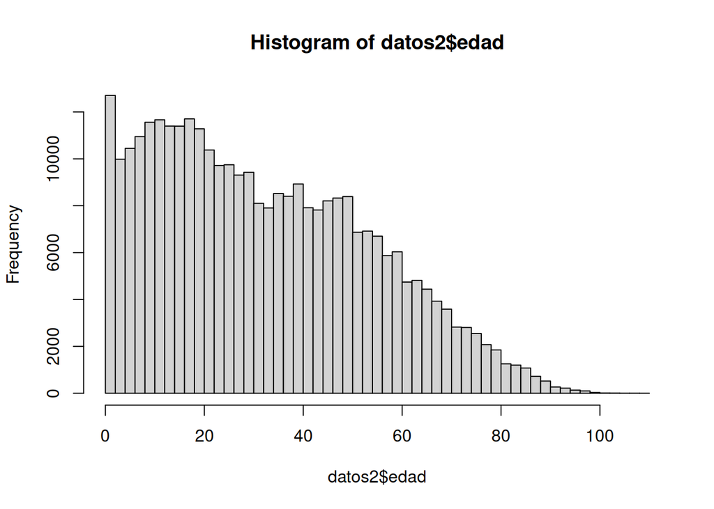

```r
hist(datos2$edad, breaks = 60) # breaks determina cuántas marcas de clase hay en el histograma
```

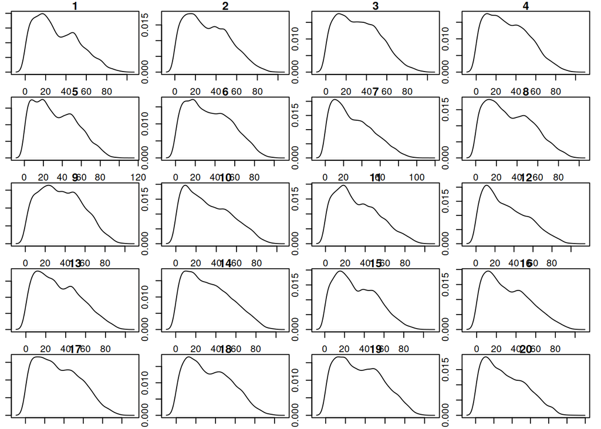

```r
par(mfrow=c(5,4))
par(mar = c(1,1,1,1))
datos2$entidad <- as.numeric(datos2$entidad)
for(i in 1:20){
  p1 <- datos2[datos2$entidad == i,]
  plot(density(p1$edad), main = i, ylab = "")
}
```

¿Cuál es la media por estado? Calculamos un intervalo de confianza del 95%. Podemos crear una lista o un data frame

```r
A <- tapply(datos2$edad,datos2$entidad,function(x)
                          c(mean(x) - qnorm(0.975)*sd(x)/sqrt(length(x)),
                            mean(x),
                            mean(x) + qnorm(0.975)*sd(x)/sqrt(length(x))))

# Convierte la lista a un dataframe y pone nombre a las columnas
A <- t(sapply(A,c))
colnames(A) <- c("liminf", "media","limsup")
```

¿Qué conclusión se saca para la hipótesis de que la edad media de Aguascalientes es mayor que 32?

Veamos ahora los tiempos de espera para recibir atención médica, ¿qué tipo de distribución parece?

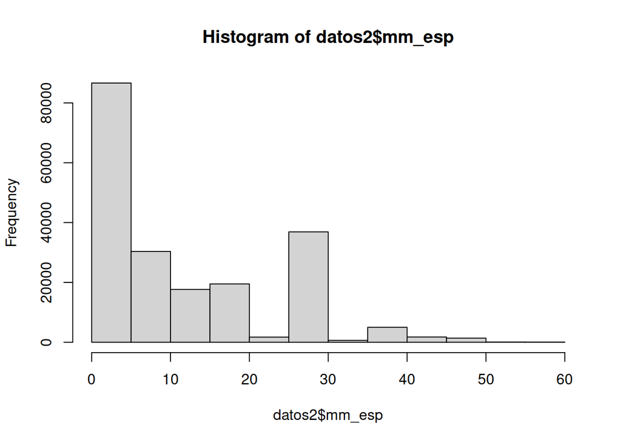

```r
hist(datos2$mm_esp)
```

Si suponemos que el tiempo de espera es una variable exponencial, ¿qué parámetro usaríamos como media?

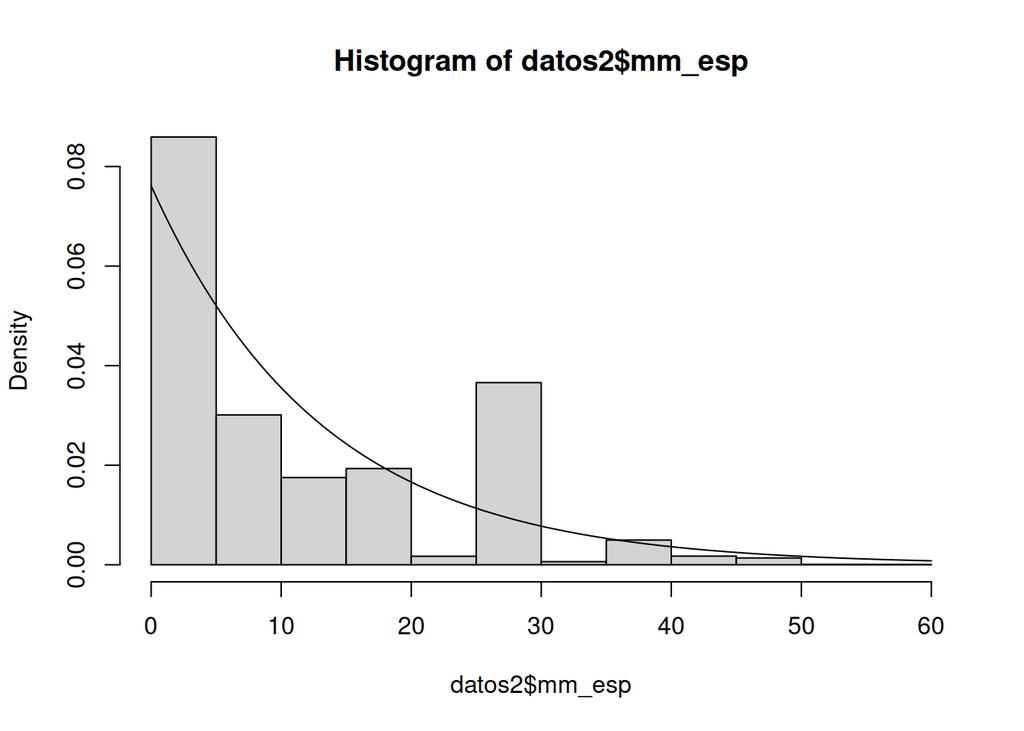

```r
lambda <- mean(datos2$mm_esp, na.rm =T)
hist(datos2$mm_esp,breaks = 20, prob = T)
curve(dexp(x,rate = 1/lambda), from = 0, to = 60, add = T)
```

### Otros formatos

```r
library(foreign)
datos <- read.spss("https://jvega68.github.io/R_docentes/datos/ENFADEA/BD_embarazo_adolescente.sav",
                   use.value.labels = T,
                   to.data.frame = T,
                   trim.factor.names = F,
                   use.missings = T,
                   duplicated.value.labels = "condense")
```

```
re-encoding from CP1252
```

```r
str(datos)
```

```
'data.frame':   91635 obs. of  716 variables:
 $ FOLCAP        : num  1 2 2 4 4 4 4 4 4 6 ...
 $ NCUEST        : num  2486 2487 2487 2489 2489 ...
 $ RUTA          : num  1 1 1 1 1 1 1 1 1 1 ...
 $ REGION        : Factor w/ 5 levels "Región 1","Región 2",..: 1 1 1 1 1 1 1 1 1 1 ...
 $ ENTIDAD       : Factor w/ 32 levels "Aguascalientes",..: 2 2 2 2 2 2 2 2 2 2 ...
 $ MUNICIPIO     : num  4 4 4 4 4 4 4 4 4 4 ...
 $ LOCALIDAD     : num  1 1 1 1 1 1 1 1 1 1 ...
 $ AGEBH         : chr  "0051" "0051" "0051" "0051" ...
 $ MANZANA       : num  31 31 31 31 31 31 31 31 31 31 ...
 $ VIVIENDA      : num  1 2 2 4 4 4 4 4 4 6 ...
 $ N_HOGAR       : Factor w/ 10 levels "Uno de uno","Uno de dos",..: 1 1 1 1 1 1 1 1 1 1 ...
 $ VISITAH       : num  1 1 1 1 1 1 1 1 1 2 ...
 $ DIAH.1        : num  28 28 28 28 28 28 28 28 28 28 ...
 $ DIAH.2        : num  NA NA NA NA NA NA NA NA NA 28 ...
```

[output cut: 89 more lines]